# Case Study 3

Lance Dacy, Reanan McDaniel, Shawn Jung, Jonathan Tan

```r
#analysis packages
library(tswge)
library(changepoint)
library(tseries)
#data manipulation
library(dplyr)
library(lubridate)
library(tibbletime)
```

```r
#visualization
library(ggplot2)
library(cowplot)
library(kableExtra)
#data source
library(cdcfluview)
```

import data from cdc flu

```r
original_data <- ilinet(region = 'national',  years = seq(1997, 2018, 1))
head(original_data)
```

| region_type | region | year | week | weighted_ili | unweighted_ili | age_0_4 | age_25_49 | age_25_64 | age_5_24 | age_50_64 | age_65 | ilitotal | num_of_providers | total_patients | week_start |
| --- | --- | --- | --- | --- | --- | --- | --- | --- | --- | --- | --- | --- | --- | --- | --- |
| National | National | 1997 | 40 | 1.10148 | 1.21686 | 179 | NA | 157 | 205 | NA | 29 | 570 | 192 | 46842 | 1997-09-28 |
| National | National | 1997 | 41 | 1.20007 | 1.28064 | 199 | NA | 151 | 242 | NA | 23 | 615 | 191 | 48023 | 1997-10-05 |
| National | National | 1997 | 42 | 1.37876 | 1.23906 | 228 | NA | 153 | 266 | NA | 34 | 681 | 219 | 54961 | 1997-10-12 |
| National | National | 1997 | 43 | 1.19920 | 1.14473 | 188 | NA | 193 | 236 | NA | 36 | 653 | 213 | 57044 | 1997-10-19 |
| National | National | 1997 | 44 | 1.65618 | 1.26112 | 217 | NA | 162 | 280 | NA | 41 | 700 | 213 | 55506 | 1997-10-26 |
| National | National | 1997 | 45 | 1.41326 | 1.28275 | 178 | NA | 148 | 281 | NA | 48 | 655 | 195 | 51062 | 1997-11-02 |

#simple series 1997 is incomplete, so lets stick to 1998-2018 (trim 1997 data) looking at total patients only also let’s convert year and week into date format

note, week 53 is usually the last less than 6 days of that year, either rolls over into the next year, overlapping with the next week 1, or an update of those last less than 6 days. either way, can justify dropping all the 53rd weeks, for the sake of calendrial neatness and to avoid overlapping numbers

```r
fdata <- original_data[, c('year', 'week', 'total_patients')] %>% filter(year %in% (1998:2018))
fdata <- fdata %>% filter(week %in% (1:52))

#year and week to date conversion, using as.Date formatting, %U for week (1:53) %u for day of week (1 is monday)
#as.Date('1998011', '%Y%U%u') #sprintf is to make sure the week input stays 2 digits long

temp_date = vector() #storage vector

for(i in 1:nrow(fdata)){
  x <- as.Date(paste(as.character(fdata$year[i]), sprintf('%02d', fdata$week[i]), '1'), '%Y%U%u')
  #x <- fdata$year[i] %>% as.character() %>% paste(sprintf('%02d', fdata$week[i]), '1') %>% as.Date('%Y%U%u') #pipe version is a little easier to read?
  #print(paste(i, fdata$year[i], fdata$week[i], x))
  temp_date[i] <- as.character(x)
}

fdata['date'] <- as.Date(temp_date)
#y <- as_tbl_time(fdata, index = date)

head(fdata)
```

| year | week | total_patients | date |
| --- | --- | --- | --- |
| 1998 | 1 | 67228 | 1998-01-05 |
| 1998 | 2 | 70828 | 1998-01-12 |
| 1998 | 3 | 67898 | 1998-01-19 |
| 1998 | 4 | 69999 | 1998-01-26 |
| 1998 | 5 | 69486 | 1998-02-02 |
| 1998 | 6 | 66322 | 1998-02-09 |

EDA - use tswge package to look at key attributes of a time series. plotts.sample.wge shows a realization of the time series, ACF, peridogram, and spectral density analysis

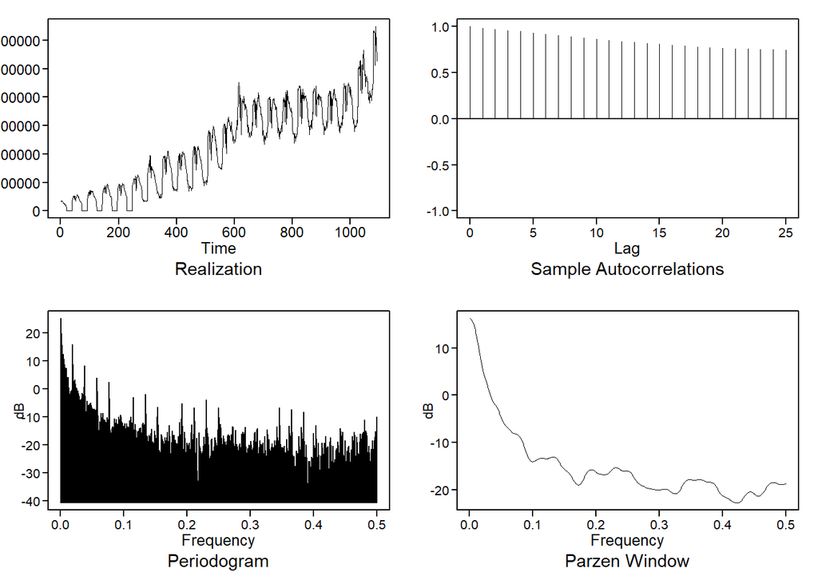

```r
#wrap objects in invisible() to hide the long console output and leave only the graph
invisible(plotts.sample.wge(fdata$total_patients))
```

lags are highly correlated, strong upwards trend with evidence of yearly seasonality, spikes approximately every 50 weeks, once a year. For a good ARIMA fit, the entirety of data is nonstationary. We need to identify a relatively stable section of the data to focus an arima on.

reasons for upwards trend in influenza diagnoses? -

- increased medical coverage/access to doctors
- increased test accuracy/knowledge of symptoms
- data set doesn’t specify which strain of flu this is, could be a new strain taking up respitory real estate from an older one - possible
- increased urbanization/chances for viruses to spread
- the slow erosion of real human resistance to continuously adapting viral evolution/more people actually geting flu than before - unlikely

changepoint analysis

```r
par(mfrow = c(2,1))

v3 <- as.ts(fdata$total_patients)

v3.pelt <- cpt.meanvar(v3, test.stat = 'Poisson', method = "PELT")
plot(v3.pelt, main = 'PELT changes in variance')
cpts.ts(v3.pelt)
```

```
##   [1]    5    7    9   11   13   15   18   20   39   41   43   46   48   50   52
##  [16]   54   56   58   60   62   64   66   68   70   72   91   93   95   97   99
##  [31]  102  104  106  108  111  113  115  117  119  122  124  143  145  147  149
##  [46]  151  154  157  159  162  164  167  169  172  174  176  195  197  199  202
##  [61]  205  207  209  212  214  217  219  222  224  226  228  247  249  251  254
##  [76]  256  259  261  264  267  269  271  273  275  278  280  282  284  286  289
##  [91]  291  294  296  299  301  303  306  308  311  313  315  318  320  322  325
## [106]  328  330  332  334  336  338  341  343  346  348  351  353  356  358  360
## [121]  362  364  367  369  371  373  375  377  380  382  384  387  390  394  396
## [136]  399  401  403  405  407  409  411  414  417  419  422  426  429  431  433
## [151]  435  437  439  441  443  446  449  452  455  457  459  462  464  466  468
## [166]  471  474  476  478  481  483  485  487  489  491  494  496  498  500  503
## [181]  505  507  509  511  513  515  517  519  521  524  529  531  533  535  537
## [196]  539  541  543  545  548  551  556  559  562  564  567  570  572  574  576
## [211]  580  582  584  586  588  590  592  594  597  599  601  603  605  608  611
## [226]  613  616  618  620  622  624  626  629  631  633  636  638  640  642  645
## [241]  649  651  653  656  658  660  663  665  667  670  672  674  676  679  681
## [256]  683  685  687  690  693  695  697  699  701  703  705  707  709  712  715
## [271]  717  720  722  724  726  728  731  733  735  737  741  743  745  747  749
## [286]  753  755  758  761  764  767  769  771  773  775  777  779  781  783  785
## [301]  787  789  792  795  797  799  801  803  806  808  810  812  814  816  819
## [316]  822  825  827  829  831  833  835  837  839  841  843  847  849  851  853
## [331]  856  858  860  862  865  868  871  874  876  878  880  883  885  888  890
## [346]  893  896  899  902  904  907  909  911  913  916  918  920  923  925  927
## [361]  930  932  934  936  939  941  943  946  948  951  953  955  957  959  961
## [376]  963  966  968  970  972  975  977  979  982  984  986  988  990  992  994
## [391]  997  999 1001 1003 1005 1007 1009 1013 1015 1021 1024 1027 1029 1032 1034
## [406] 1036 1039 1041 1043 1045 1047 1049 1052 1055 1057 1059 1061 1063 1065 1067
## [421] 1069 1071 1074 1076 1079 1081 1085 1087 1090
```

```r
v3.bs <- cpt.meanvar(v3, test.stat = 'Poisson', method = 'BinSeg')
```

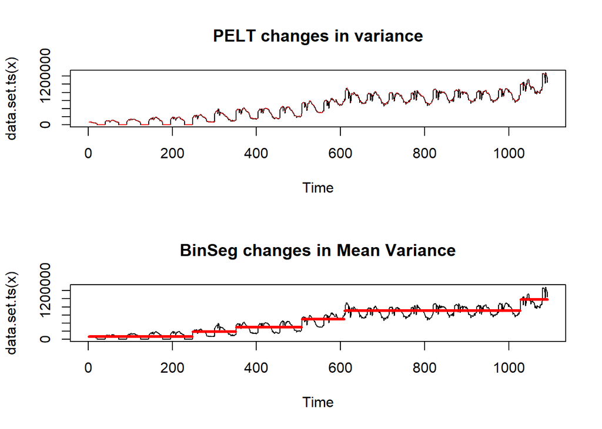

```r
plot(v3.bs, cpt.width = 3, main = 'BinSeg changes in Mean Variance')
```

```r
cpts.ts(v3.bs)
```

```
## [1]  247  351  507  608 1027
```

Changepoint analysis shows a stable time period between week 620 and 1050, or 2009 to 2017 ish (rows 573- 1040) (note, is there a way to pull out the exact mean variance continuties?)

select total flu patient numbers from 2009-2017

```r
tdata <- fdata[573:1040, 3:4]
head(tdata)
```

| total_patients | date |
| --- | --- |
| 579428 | 2009-01-05 |
| 565631 | 2009-01-12 |
| 582932 | 2009-01-19 |
| 611176 | 2009-01-26 |
| 638613 | 2009-02-02 |
| 648304 | 2009-02-09 |

visualizations

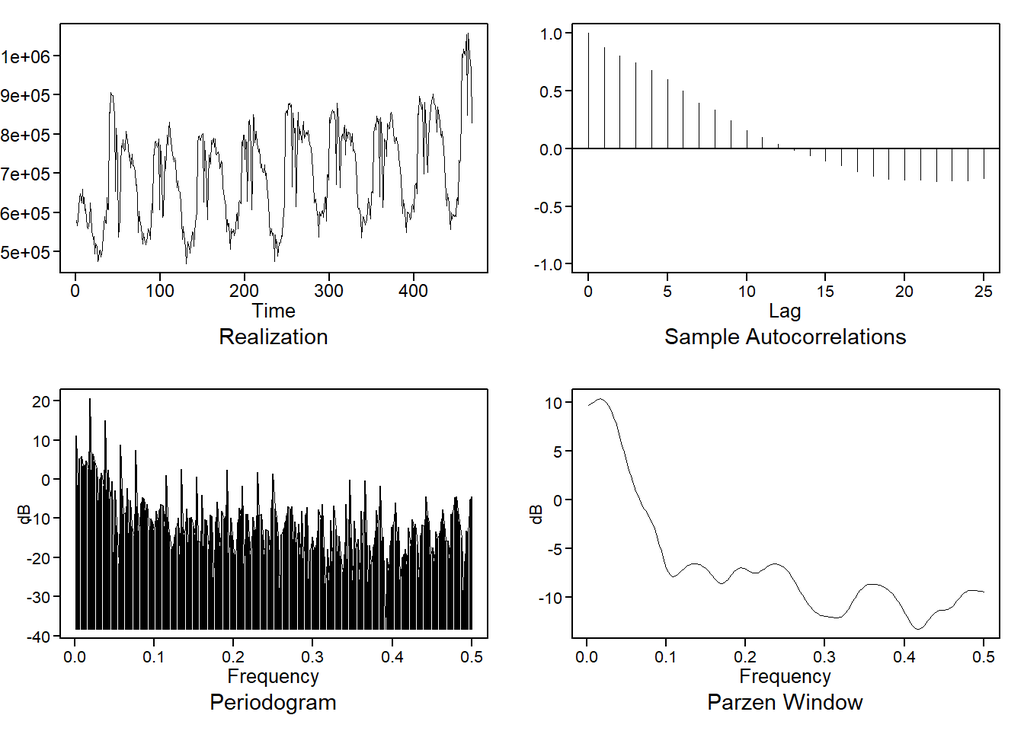

[output not shown]

[output cut: 130 more lines]

```r
plotts.sample.wge(as.integer(tdata$total_patients))
```

now we still have a bit of seasonality, but much less wandering behavior, with tapering ACF indicating stationarity. note, ARMA model requires stationarity

stationarity test - augmented dicky fuller test

```r
adf.test(tdata$total_patients)
```

```
##
##  Augmented Dickey-Fuller Test
##
## data:  tdata$total_patients
## Dickey-Fuller = -5.5589, Lag order = 7, p-value = 0.01
## alternative hypothesis: stationary
```

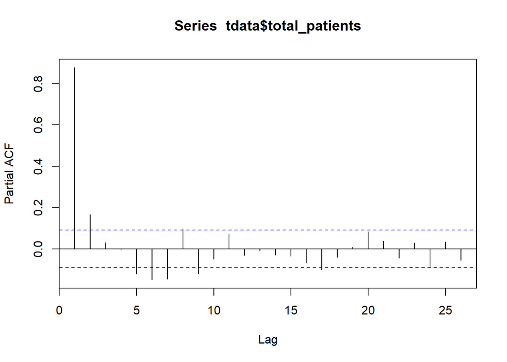

```r
pacf(tdata$total_patients)
```

quickly damping and oscliating PACF indicate strong autoregressive component

quick look at how many AR and MA factors might be used to approximate the time series with a function

```r
aic5.wge(tdata$total_patients, p = 0:5, q = 0:5)
```

```
## ---------WORKING... PLEASE WAIT...
##
##
## Error in aic calculation at 4 2
## Five Smallest Values of  aic
```

|  | p | q | aic |
| --- | --- | --- | --- |
| 12 | 1 | 5 | 21.88763 |
| 30 | 4 | 5 | 21.88781 |
| 32 | 5 | 1 | 21.89157 |
| 33 | 5 | 2 | 21.89858 |
| 23 | 3 | 4 | 21.89930 |

```r
aic5.wge(tdata$total_patients, p = 0:5, q = 0:5, type = 'bic')
```

```
## ---------WORKING... PLEASE WAIT...
##
##
## Error in aic calculation at 4 2
## Five Smallest Values of  bic
```

|  | p | q | bic |
| --- | --- | --- | --- |
| 12 | 1 | 5 | 21.94968 |
| 8 | 1 | 1 | 21.95334 |
| 32 | 5 | 1 | 21.95362 |
| 13 | 2 | 0 | 21.95440 |
| 11 | 1 | 4 | 21.96332 |

we’ll go with arma(1, 5) for now

estimating coeffients for the ARMA model

```r
m1 = est.arma.wge(tdata$total_patients, p = 1, q = 5, factor = TRUE)
```

```
##
## Coefficients of Original polynomial:
## 0.8597
##
## Factor                 Roots                Abs Recip    System Freq
## 1-0.8597B              1.1632               0.8597       0.0000
##
##
```

```r
m1$phi
```

```
## [1] 0.8596699
```

```r
m1$theta
```

```
## [1]  0.20745358 -0.06210161 -0.03770768 -0.16434549 -0.22312952
```

now we’ll slot thos phis and thetas into a forecast of the data up to 2016, and compare it to the actual data from 2017

```r
weeks_compare = 52 #how many weeks to reserve for testing
f1 <- tdata$total_patients[1:(nrow(tdata)-weeks_compare)] %>% fore.aruma.wge(phi = m1$phi, theta = m1$theta, n.ahead = weeks_compare)
```

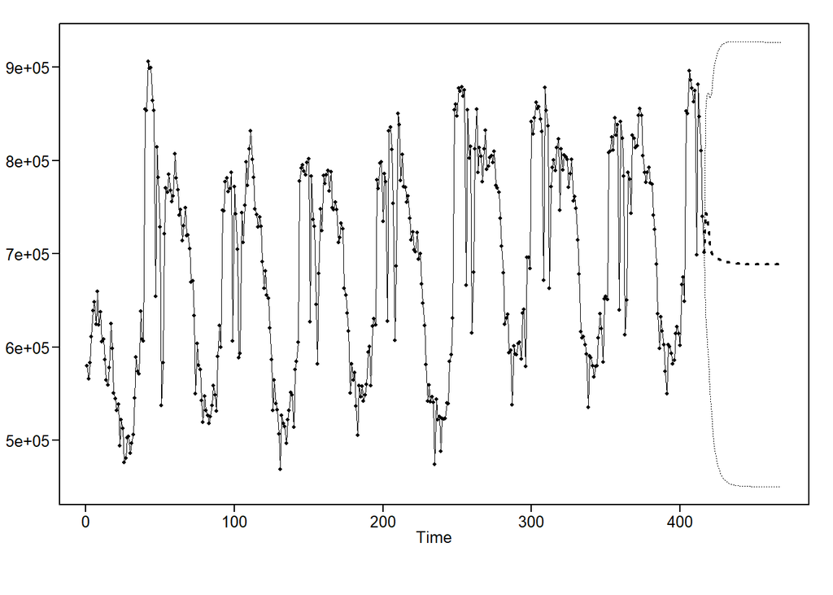

```r
#MSE compare actual data to f1$f
mse <- (tdata$total_patients[((nrow(tdata)-weeks_compare)+1):(nrow(tdata))] - f1$f)^2 %>% mean()
paste('Mean Squared Error: ', mse)
```

```
## [1] "Mean Squared Error:  32546468310.4466"
```

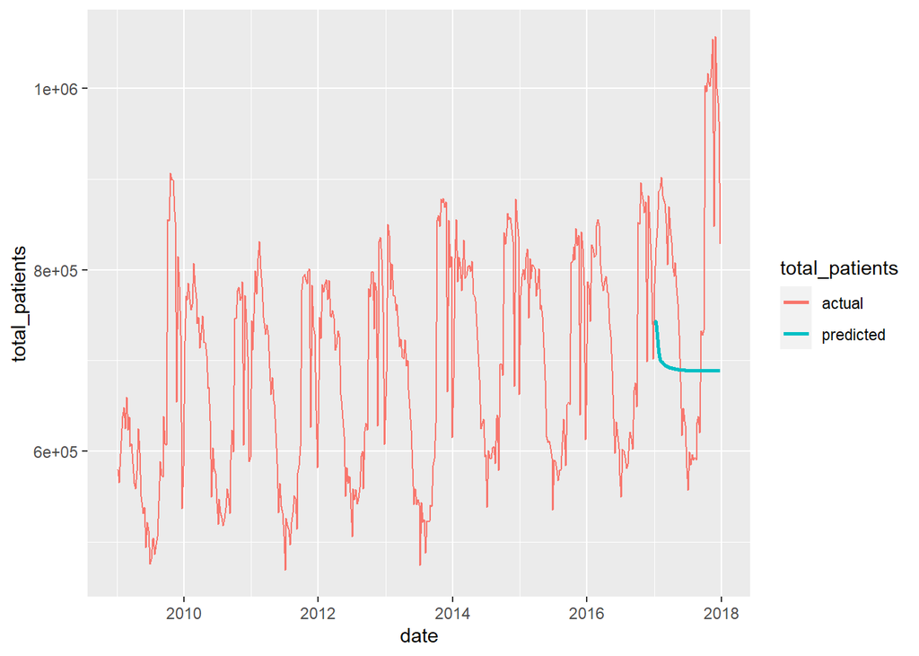

```r
g1 <- ggplot(tdata)+
  geom_line(aes(x = date, y = total_patients, color = 'black'), size = 0.5)+
  geom_line(aes(x = date, y = c(rep(NA, nrow(tdata)-weeks_compare), f1$f), color = 'red'), size= 1) +
  scale_color_discrete(name = "total_patients", labels = c('actual', 'predicted'))
g1
```

not great, clearly an arma(1, 5) doesn’t fit the data well. let’s expand AIC parameters

```r
aic5.wge(tdata$total_patients, p = 0:10, q = 0:5)
```

```
## ---------WORKING... PLEASE WAIT...
##
##
## Error in aic calculation at 4 2
## Five Smallest Values of  aic
```

|  | p | q | aic |
| --- | --- | --- | --- |
| 65 | 10 | 4 | 21.85707 |
| 52 | 8 | 3 | 21.86241 |
| 45 | 7 | 2 | 21.86458 |
| 55 | 9 | 0 | 21.86491 |
| 62 | 10 | 1 | 21.86595 |

```r
aic5.wge(tdata$total_patients, p = 0:10, q = 0:5, type = 'bic')
```

```
## ---------WORKING... PLEASE WAIT...
##
##
## Error in aic calculation at 4 2
## Five Smallest Values of  bic
```

|  | p | q | bic |
| --- | --- | --- | --- |
| 12 | 1 | 5 | 21.94968 |
| 43 | 7 | 0 | 21.95187 |
| 44 | 7 | 1 | 21.95191 |
| 45 | 7 | 2 | 21.95322 |
| 8 | 1 | 1 | 21.95334 |

let’s try (7, 0) ARMA, no differences

```r
m2 = est.arma.wge(tdata$total_patients, p = 7, q = 0, factor = TRUE)
```

```
##
## Coefficients of Original polynomial:
## 0.6654 0.1735 0.0878 0.1211 0.0279 -0.0735 -0.1473
##
## Factor                 Roots                Abs Recip    System Freq
## 1-1.7863B+0.8179B^2    1.0920+-0.1735i      0.9044       0.0251
## 1-0.3953B+0.5933B^2    0.3331+-1.2548i      0.7703       0.2087
## 1+0.6765B             -1.4783               0.6765       0.5000
## 1+0.8397B+0.4489B^2   -0.9354+-1.1631i      0.6700       0.3578
##
##
```

```r
m2$phi
```

```
## [1]  0.66540087  0.17351458  0.08779879  0.12114317  0.02788943 -0.07347893
## [7] -0.14734338
```

```r
m2$theta
```

```
## [1] 0
```

```r
weeks_compare = 26 #how many weeks to reserve for testing
f2 <- tdata$total_patients[1:(nrow(tdata)-weeks_compare)] %>% fore.aruma.wge(phi = m2$phi, theta = m2$theta, n.ahead = weeks_compare)
```

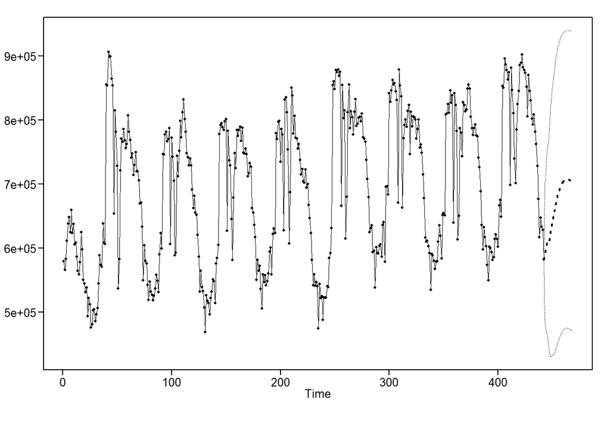

```r
mse <- (tdata$total_patients[((nrow(tdata)-weeks_compare)+1):(nrow(tdata))] - f2$f)^2 %>% mean()
paste('Mean Squared Error: ', mse)
```

```
## [1] "Mean Squared Error:  42159251698.538"
```

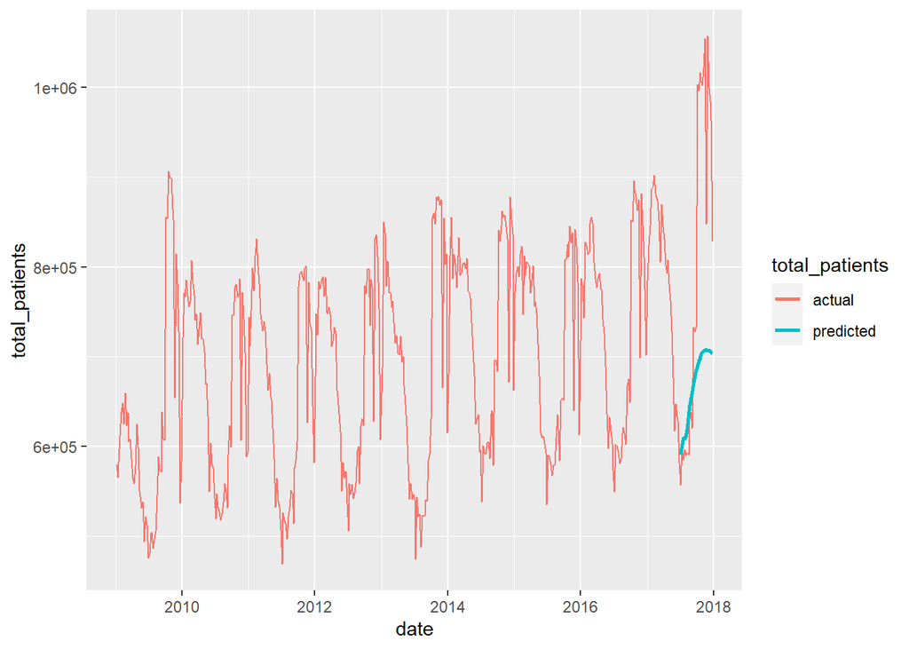

```r
g2 <- ggplot(tdata)+
  geom_line(aes(x = date, y = total_patients, color = 'black'), size = 0.5)+
  geom_line(aes(x = date, y = c(rep(NA, nrow(tdata)-weeks_compare), f2$f), color = 'red'), size= 1) +
  scale_color_discrete(name = "total_patients", labels = c('actual', 'predicted'))
g2
```

use artrans to remove seasonality, take first difference of time series.

```r
d1 <- artrans.wge(tdata$total_patients, phi.tr = 1)
```

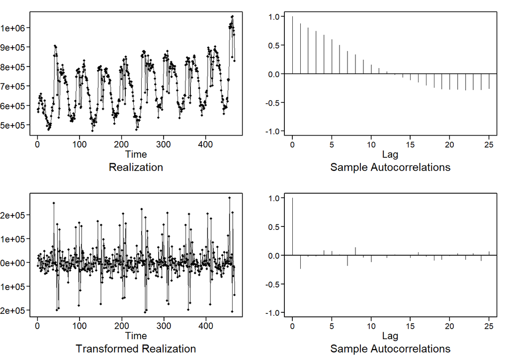

now run the differenced data through the previous steps

```r
aic_results <- aic5.wge(d1, p = 0:10, q = 0:5)
```

```
## ---------WORKING... PLEASE WAIT...
##
##
## Error in aic calculation at 3 3
## Five Smallest Values of  aic
```

```r
bic_results <- aic5.wge(d1, p = 0:10, q = 0:5, type = 'bic')
```

```
## ---------WORKING... PLEASE WAIT...
##
##
## Error in aic calculation at 3 3
## Five Smallest Values of  bic
```

```r
m3 = est.arma.wge(d1, p = aic_results[1, 1], q = aic_results[1, 2], factor = TRUE)
```

```
##
## Coefficients of Original polynomial:
## -0.1281 0.1311 0.3270 -0.2620 -0.3984 -0.1332 -0.2570
##
## Factor                 Roots                Abs Recip    System Freq
## 1-1.6762B+0.9211B^2    0.9099+-0.5077i      0.9597       0.0810
## 1+1.0825B+0.8421B^2   -0.6428+-0.8800i      0.9176       0.3504
## 1+0.8021B             -1.2468               0.8021       0.5000
## 1-0.0803B+0.4130B^2    0.0972+-1.5529i      0.6427       0.2401
##
##
```

```r
m3$phi
```

```
## [1] -0.1281398  0.1311266  0.3270281 -0.2620236 -0.3983738 -0.1331568 -0.2569587
```

```r
m3$theta
```

```
## [1]  0.1879895  0.2012805  0.2734520 -0.5291232 -0.4727068
```

```r
diff_df <- data.frame(tdata$date[1:(nrow(tdata)-1)], d1)
names(diff_df) <- c('date', 'total_patients')

weeks_compare = 26 #how many weeks to reserve for testing
f3 <- diff_df$total_patients[1:(nrow(tdata)-weeks_compare)] %>% fore.aruma.wge(phi = m2$phi, theta = m2$theta, d = 1, n.ahead = weeks_compare)
```

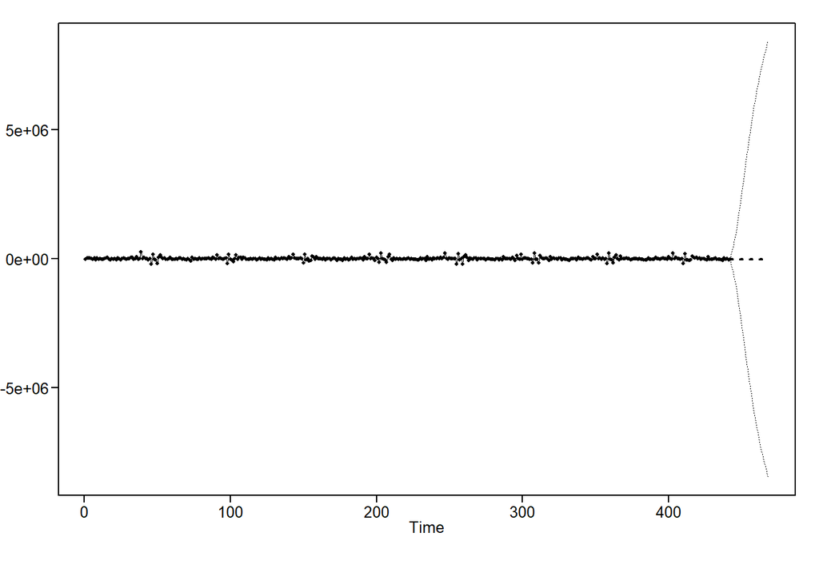

```r
mse <- (diff_df$total_patients[((nrow(diff_df)-weeks_compare)+1):(nrow(diff_df))] - f3$f)^2 %>% mean()
paste('Mean Squared Error: ', mse)
```

```
## [1] "Mean Squared Error:  8508265556.55765"
```

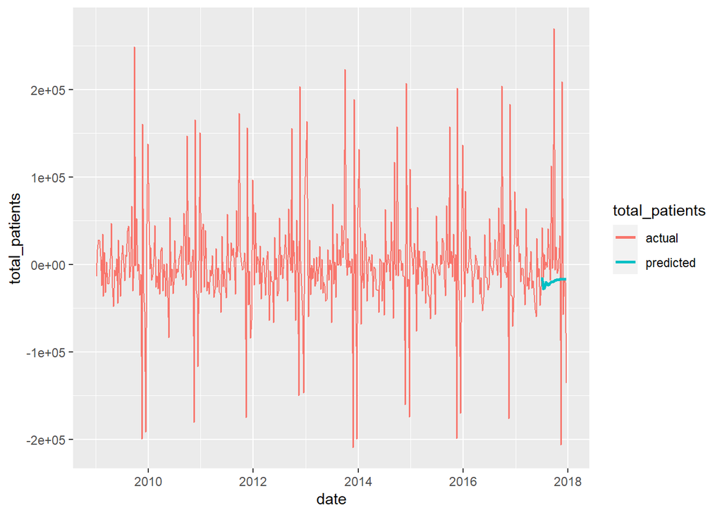

```r
g3 <- ggplot(diff_df)+
  geom_line(aes(x = date, y = total_patients, color = 'black'), size = 0.5)+
  geom_line(aes(x = date, y = c(rep(NA, nrow(diff_df)-weeks_compare), f3$f), color = 'red'), size= 1) +
  scale_color_discrete(name = "total_patients", labels = c('actual', 'predicted'))
g3
```

still not great

more tuning to do on pdq, then setup rolling ASE/other evaluation metric? cross validation to add too